# Lab 4

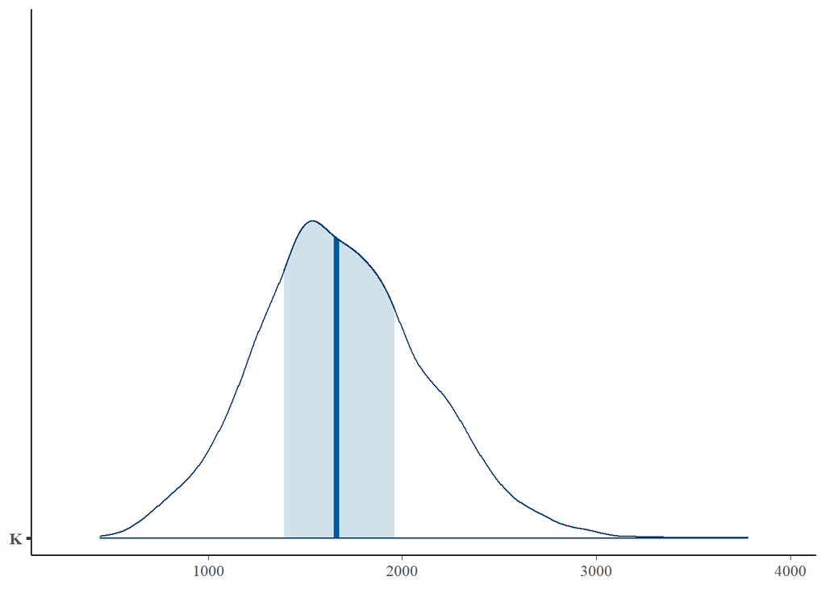

```r
bayesplot::mcmc_areas(posterior, pars = c('K'))
```

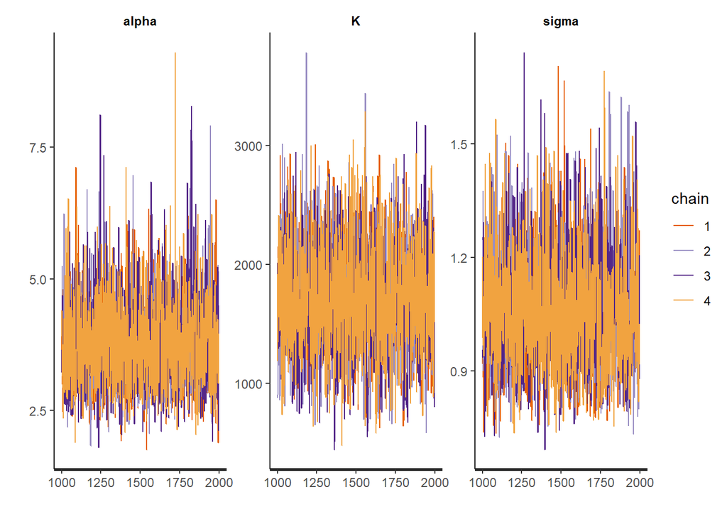

```r
rstan::traceplot(mod1, pars = c('alpha', 'K', 'sigma'))
```

Our caterpillars are looking nice and fuzzy! Next up, we’ll run a quick posterior predictive check (pp check!!), to see how well our model is able to reproduce a similar dataset to what we used to create it. If you run a model in `brms` or `rstanarm`, there are default functions you can use to do this quickly, but we have to add in an extra step to convert our model output to a nice format for plotting.

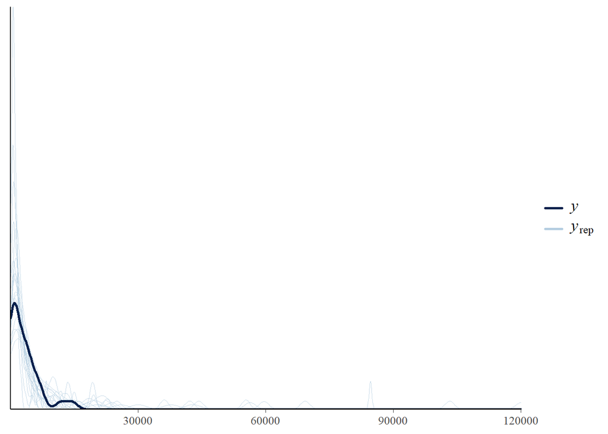

```r
#calculate the total number of iterations actually stored in our model object
total_iter <- (iter-warmup)*chains
#extract our y_ppd values for a subset of iterations
#this code is a little janky, but it works! Feel free to play around and make it
#prettier
yrep_extract <- function(model, yrep_name){
  as.data.frame(rstan::extract(model, pars = yrep_name)[[1]]) %>%
  rownames_to_column() %>%
  mutate(rowname = as.numeric(rowname)) %>%
  filter(rowname%in%c(sample(1:total_iter, 50, replace = FALSE))) %>%
  dplyr::select(-rowname) %>%
  as.matrix()
}
#now we can feed these extracted values into our ppcheck function
bayesplot::ppc_dens_overlay(df$R, yrep=yrep_extract(mod1, "y_ppd"))
```

What we’re looking for in the posterior predictive check is to see if our simulated data (i.e., “y_rep”, or the light blue lines) line up reasonably well with our real data (i.e. “y”, or the dark blue line). In this case, our model isn’t too bad! It looks like we might be slightly overpredicting the number of small values and underpredicting some of the mid-range values, but our dark blue line always has some light blue above and below it, which is a good sign.

Next up, let’s check whether we have any weird patterns going on in our residuals. I love using the `DHARMa` package for this, because it automatically standardizes everything so you can use it regardless of what kind of distributions you’re using.

As with our pp check, `rstan` objects don’t play nice with our convenient functions, so we have to make our own function to get stuff in the right format for DHARMa:

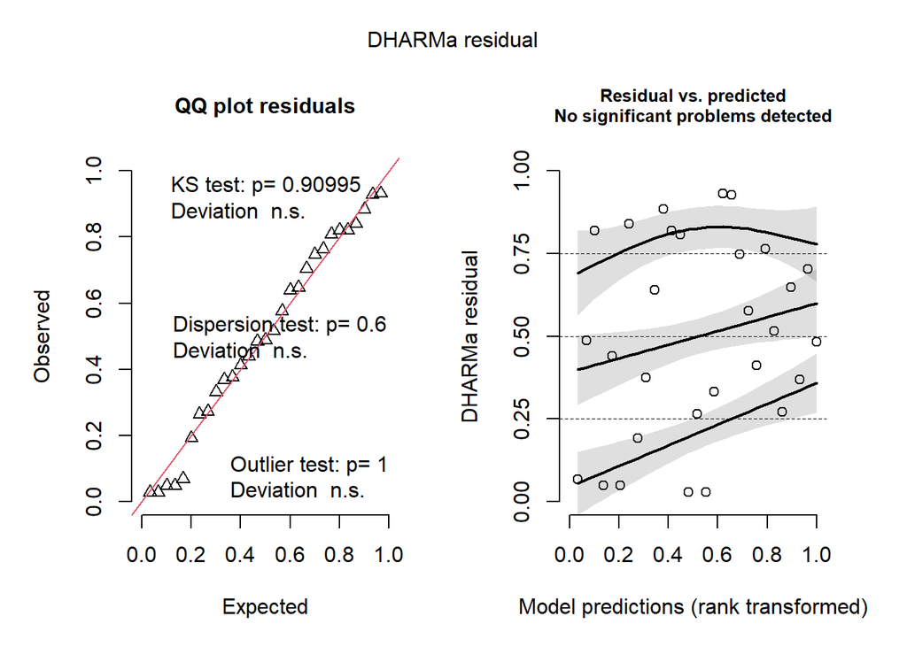

```r
dharma_resids <- function(model, iter, response, y_ppd = "y_ppd"){
  #extract model predictions based on our generated quantities section (the y_ppd variable)
  predictions <- as.data.frame(rstan::extract(model,
                             pars = y_ppd)[[1]]) %>%
    #get things in the right format
    rownames_to_column() %>%
    pivot_longer(!rowname,
                 names_to = "obs",
                 values_to = "y_ppd") %>%
    mutate(rowname = as.numeric(rowname))
  # randomly select 250 draws
  sim_response_matrix <-
    data.frame(rowname = sample(1:iter, 250, replace = FALSE)) %>%
    #left_join will grab only the rows in predictions that line up with the row
    #names we randomly generated above
    left_join(predictions, by = "rowname") %>%
    #remove obs so we can pivot wider without pissing it off
    dplyr::select(-obs) %>%
    group_by(rowname) %>%
    mutate(row = row_number()) %>%
    #get everything back in the right format
    pivot_wider(id_cols = everything(), names_from = 'rowname', values_from = 'y_ppd') %>%
    dplyr::select(-row) %>%
    as.matrix()
  #calculate the residuals using the simulated responses and the actual raw data
  resids <- DHARMa::createDHARMa(simulatedResponse = sim_response_matrix,
                       observedResponse = response,
                       fittedPredictedResponse = apply(t(sim_response_matrix), 2, median),
                       integerResponse = FALSE)
  return(resids)
}

#run our custom function on our model and with our raw data
resids <- dharma_resids(mod1, iter, df$R)
plot(resids)
```

DHARMa creates two plots for us and runs three different tests that can help us figure out what (if anything) is wrong with our model. On the left panel, we see a qqplot of the standardized residuals - these should fall roughly along the straight line in a model that fits reasonably well. There are also the results of the three tests printed directly onto the panel - these will turn red if your model fails them! The KS test tells you if you’ve picked a reasonable distribution for your data (see the distributions section below for more details about that), the dispersion test tells you if your data are more or less dispersed than expected for your model (which can also give you a clue as to whether you’ve chosen the right distribution), and the outlier test tells you if any of your observations are statistical outliers that may be having a disproportionate influence on your model. On the right panel, we see a plot of our standardized residuals against the standardized model predictions - this helps us see if there is any weird patterning in our residuals and to look for issues like heteroskedasticity (i.e., if the amount of spread of our data around the modelled line increases with certain values of our predictor).

Note that `DHARMa` does significance testing - which means that if you have a massive sample size, you’re almost always going to fail the tests! So red isn’t an automatic indicator of doom - just an invitation to use your judgement.

Finally, let’s plot our model estimates onto our data to see if they make sense!

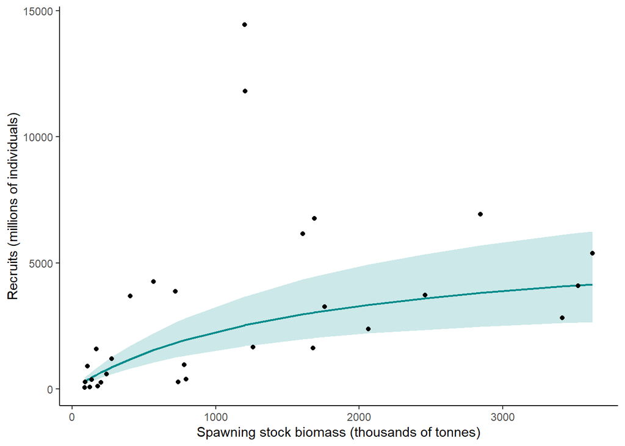

```r
#extract the parameter estimates from our model
#extract() will create a list with every parameter, and each parameter will have
#one column for every element we defined in the stan file, and one row for every
#iteration we've kept from the model
params1 <- rstan::extract(mod1)

#extract our mean recruit estimates
mean_recruits <- params1$mean_recruits
#and our randomly generated predictions
pred_recruits <- params1$y_ppd

#extract the median and 95% CI across the SSBs in our dataset
#we'll make an empty matrix ro feed our median and CIs into
med_mat <- data.frame(median_fit=NA,l.95.ci=NA,u.95.ci=NA)
#then, since we have one column for each observation in our original dataset,
#we'll run a for loop to do each calculation for each column
for(i in 1:ncol(mean_recruits)){
  #take the median within each column
  med_mat[i,1]=median(mean_recruits[,i])
  #the the upper and lower CIs
  med_mat[i,2]=quantile(mean_recruits[,i],0.025)
  med_mat[i,3]=quantile(mean_recruits[,i],0.975)
}

#we'll do the same thing with the predictions we generated in the generated
#quantities section
#this time, the 2.5% and 97.5% quantiles will represent our 95% predicitve
#interval (i.e., our uncertainty around our estimate for any given SSB -
#remember that our CI is our uncertainty around the *mean* estimate)
pred_mat <- data.frame(median_pred=NA,l.95.pi=NA,u.95.pi=NA)
for(i in 1:ncol(pred_recruits)){
  pred_mat[i,1]=median(pred_recruits[,i])
  pred_mat[i,2]=quantile(pred_recruits[,i],0.025)
  pred_mat[i,3]=quantile(pred_recruits[,i],0.975)
}

#connect these to our original dataframe to make plotting easier
df_plot <- df %>%
  bind_cols(as.data.frame(med_mat), as.data.frame(pred_mat))

#plot!
ggplot(data = df_plot, aes(x = SSB, y = R)) +
  #plot the 95% CI
  geom_ribbon(aes(x = SSB, y = median_fit, ymin = l.95.ci, ymax = u.95.ci),
              fill='darkcyan', alpha = 0.2) +
  #and the mean model estimate
  geom_line(aes(x=SSB, y = median_fit),
            lwd=0.8, col = "darkcyan") +
  #and throw in the raw data for funsies (and because it's generally a good rule
  #of thumb to show the raw data so readers can judge for themselves whether or
  #not your model is total crap)
  geom_point() +
  theme_classic() +
  labs(x = "Spawning stock biomass (thousands of tonnes)",
       y = "Recruits (millions of individuals)")
```

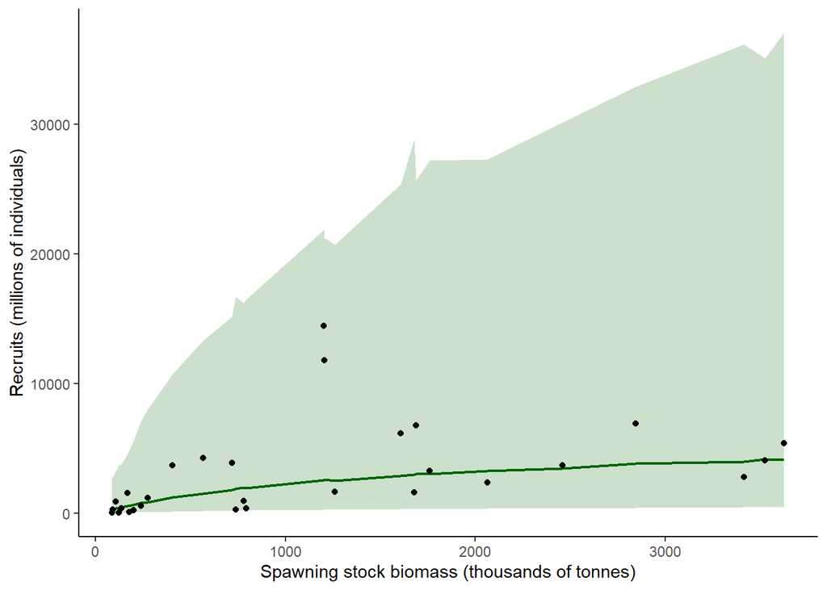

```r
#do the same thing here but with our predictions rather than our mean estimate
ggplot(data = df_plot, aes(x = SSB, y = R)) +
  geom_ribbon(aes(x = SSB, y = median_pred, ymin = l.95.pi, ymax = u.95.pi),
              fill='darkgreen', alpha = 0.2) +
  geom_line(aes(x=SSB, y = median_pred),
            lwd=0.8, col = "darkgreen") +
  geom_point() +
  theme_classic() +
  labs(x = "Spawning stock biomass (thousands of tonnes)",
       y = "Recruits (millions of individuals)")
```

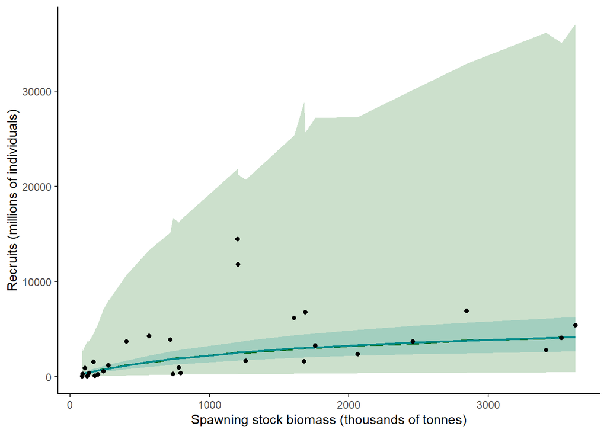

```r
#and we can combine them here to show just how much of a crapshoot a lot of
#fisheries management is, and how people are lying to themselves if they only
#look at uncertainty in the mean
ggplot(data = df_plot, aes(x = SSB, y = R)) +
  geom_ribbon(aes(x = SSB, y = median_pred, ymin = l.95.pi, ymax = u.95.pi),
              fill='darkgreen', alpha = 0.2) +
  geom_line(aes(x=SSB, y = median_pred),
            lty=5,lwd=0.8, col = "darkgreen") +
  geom_ribbon(aes(x = SSB, y = median_fit, ymin = l.95.ci, ymax = u.95.ci),
              fill='darkcyan', alpha = 0.2) +
  geom_line(aes(x=SSB, y = median_fit),
            lwd=0.8, col = "darkcyan") +
  geom_point() +
  theme_classic() +
  labs(x = "Spawning stock biomass (thousands of tonnes)",
       y = "Recruits (millions of individuals)")
```

Note in the example above, we took the median value of our chains to represent our central tendancy, rather than the mean. We could also easily take the mean instead! The only issue with that, is that our 95% predictive interval extends to such high values, that it will drastically increase the mean (even though there is a low probability of those extremely high values).

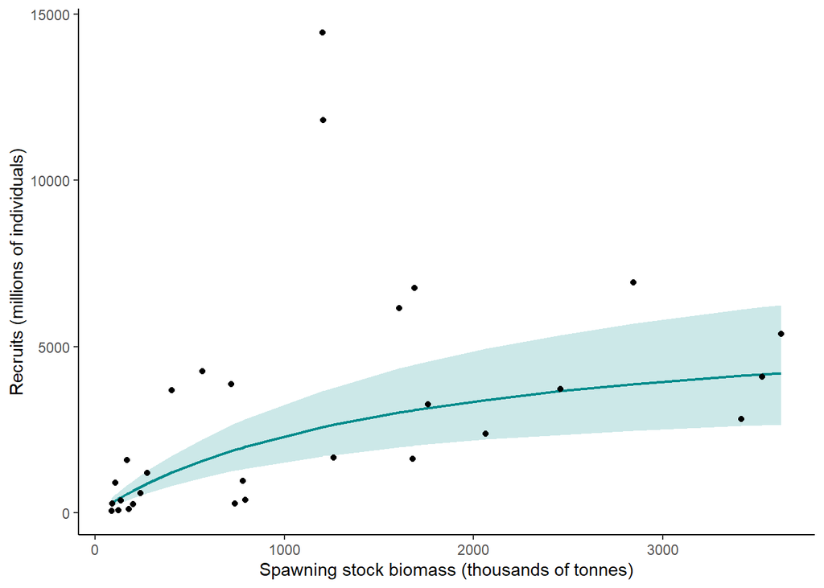

```r
#extract the median and 95% CI across the SSBs in our dataset
#we'll make an empty matrix ro feed our median and CIs into
mean_mat <- data.frame(mean_fit=NA,l.95.ci=NA,u.95.ci=NA)
#then, since we have one column for each observation in our original dataset,
#we'll run a for loop to do each calculation for each column
for(i in 1:ncol(mean_recruits)){
  #take the median within each column
  mean_mat[i,1]=mean(mean_recruits[,i])
  #the the upper and lower CIs
  mean_mat[i,2]=quantile(mean_recruits[,i],0.025)
  mean_mat[i,3]=quantile(mean_recruits[,i],0.975)
}

#we'll do the same thing with the predictions we generated in the generated
#quantities section
#this time, the 2.5% and 97.5% quantiles will represent our 95% predicitve
#interval (i.e., our uncertainty around our estimate for any given SSB -
#remember that our CI is our uncertainty around the *mean* estimate)
mean_pred_mat <- data.frame(mean_pred=NA,l.95.pi=NA,u.95.pi=NA)
for(i in 1:ncol(pred_recruits)){
  mean_pred_mat[i,1]=mean(pred_recruits[,i])
  mean_pred_mat[i,2]=quantile(pred_recruits[,i],0.025)
  mean_pred_mat[i,3]=quantile(pred_recruits[,i],0.975)
}

#connect these to our original dataframe to make plotting easier
df_plot2 <- df %>%
  bind_cols(as.data.frame(mean_mat), as.data.frame(mean_pred_mat))

#plot!
ggplot(data = df_plot2, aes(x = SSB, y = R)) +
  #plot the 95% CI
  geom_ribbon(aes(x = SSB, y = mean_fit, ymin = l.95.ci, ymax = u.95.ci),
              fill='darkcyan', alpha = 0.2) +
  #and the mean model estimate
  geom_line(aes(x=SSB, y = mean_fit),
            lwd=0.8, col = "darkcyan") +
  #and throw in the raw data for funsies (and because it's generally a good rule
  #of thumb to show the raw data so readers can judge for themselves whether or
  #not your model is total crap)
  geom_point() +
  theme_classic() +
  labs(x = "Spawning stock biomass (thousands of tonnes)",
       y = "Recruits (millions of individuals)")
```

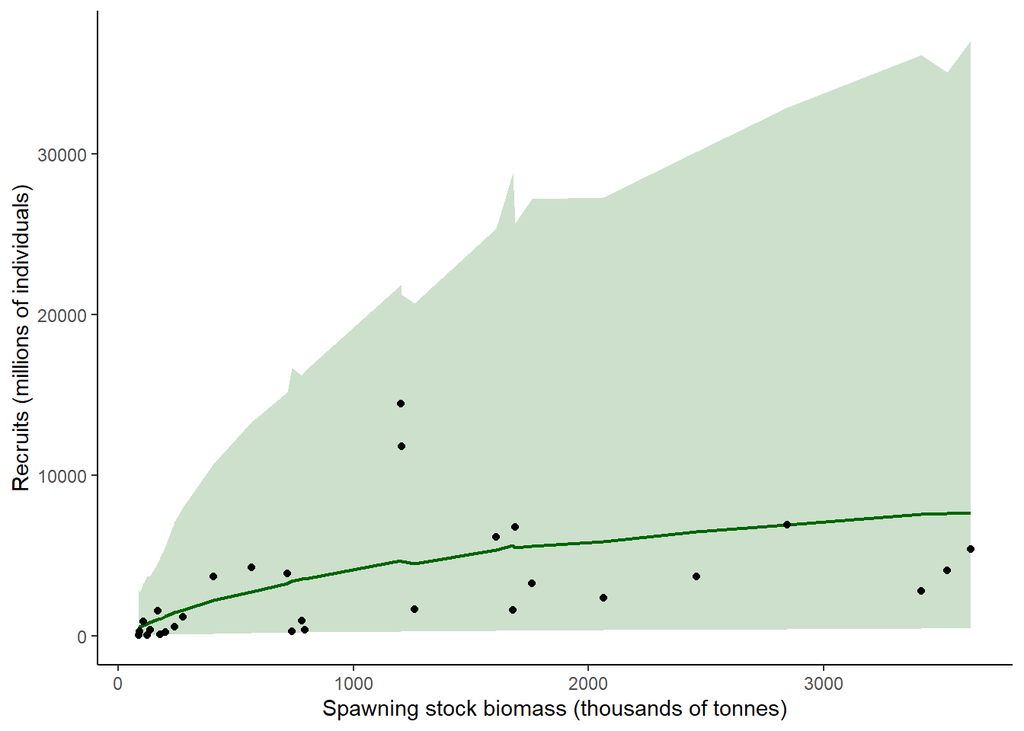

```r
#do the same thing here but with our predictions rather than our mean estimate
ggplot(data = df_plot2, aes(x = SSB, y = R)) +
  geom_ribbon(aes(x = SSB, y = mean_pred, ymin = l.95.pi, ymax = u.95.pi),
              fill='darkgreen', alpha = 0.2) +
  geom_line(aes(x=SSB, y = mean_pred),
            lwd=0.8, col = "darkgreen") +
  geom_point() +
  theme_classic() +
  labs(x = "Spawning stock biomass (thousands of tonnes)",
       y = "Recruits (millions of individuals)")
```

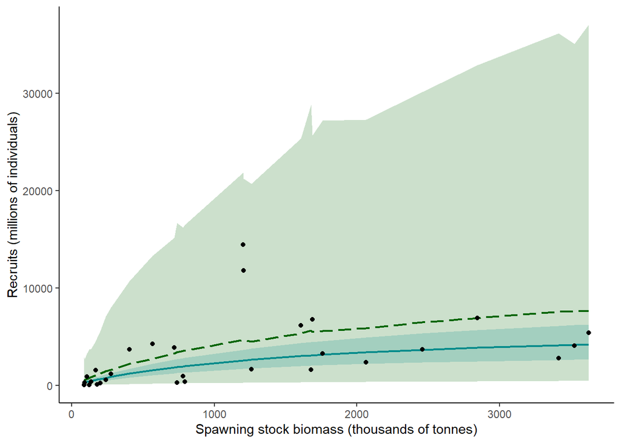

```r
#and we can combine them here to show just how much of a crapshoot a lot of
#fisheries management is, and how people are lying to themselves if they only
#look at uncertainty in the mean
ggplot(data = df_plot2, aes(x = SSB, y = R)) +
  geom_ribbon(aes(x = SSB, y = mean_pred, ymin = l.95.pi, ymax = u.95.pi),
              fill='darkgreen', alpha = 0.2) +
  geom_line(aes(x=SSB, y = mean_pred),
            lty=5,lwd=0.8, col = "darkgreen") +
  geom_ribbon(aes(x = SSB, y = mean_fit, ymin = l.95.ci, ymax = u.95.ci),
              fill='darkcyan', alpha = 0.2) +
  geom_line(aes(x=SSB, y = mean_fit),
            lwd=0.8, col = "darkcyan") +
  geom_point() +
  theme_classic() +
  labs(x = "Spawning stock biomass (thousands of tonnes)",
       y = "Recruits (millions of individuals)")
```